# Penn Masala Spotify Data Analysis 2018

## Which Album Was Most Popular?

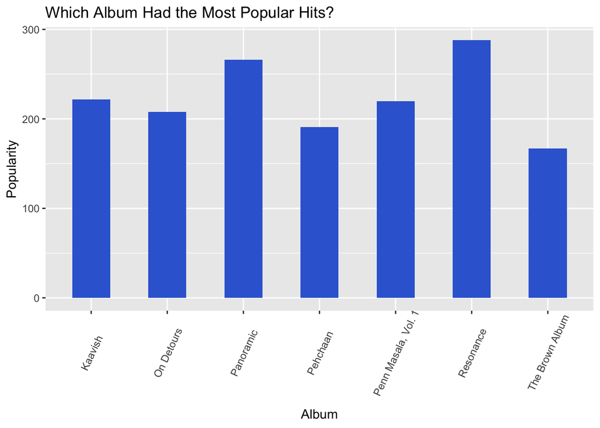

## Which Album Was Most Danceable?

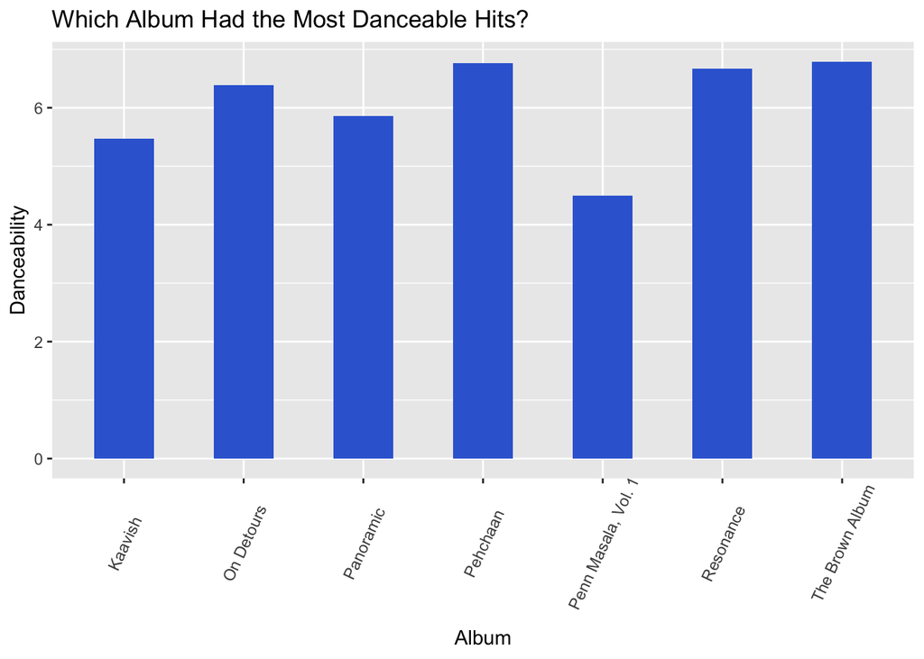

## Popularity Graph by Dancebility

##### Danceability is determined by tempo, rhythm stability, beat strength, and overall regularity.

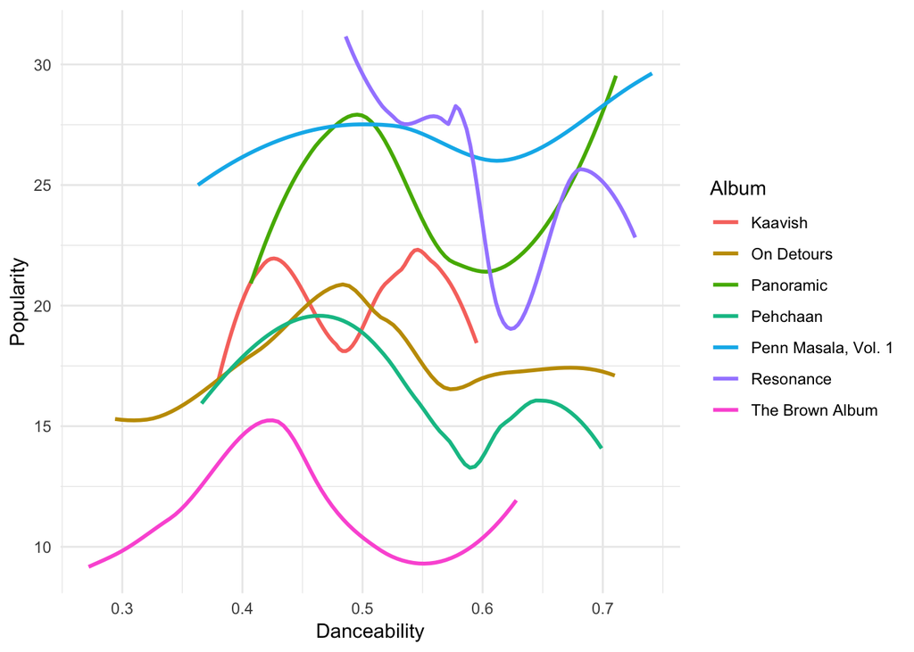

## Popularity Graph by Energy

##### Energy measures intensity and activity. Typically, energetic tracks feel fast, loud, and noisy. For example, death metal has high energy, while a Bach prelude scores low on the scale. Perceptual features contributing to this attribute include dynamic range, perceived loudness, timbre, onset rate, and general entropy.

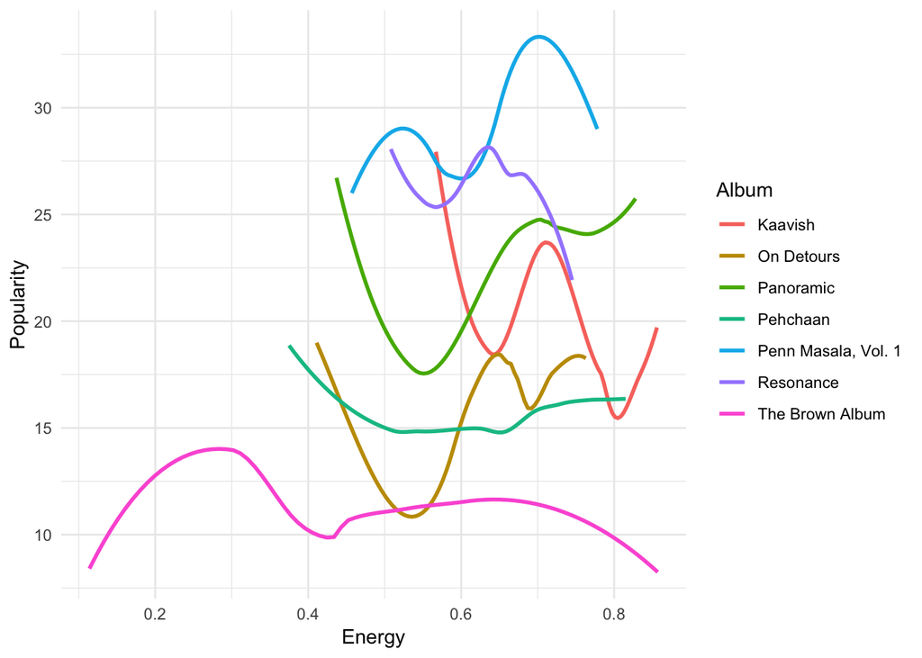

## Popularity Graph by Loudness

##### Loudness values are averaged across the entire track and are useful for comparing relative loudness of tracks. Loudness is the quality of a sound that is the primary psychological correlate of physical strength (amplitude). Values typical range between -60 and 0 db.

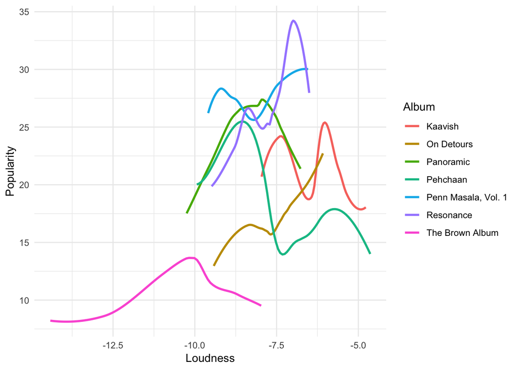

## Popularity Graph by Valence

##### Valence measures the musical positiveness conveyed by a track. Tracks with high valence sound more positive (e.g. happy, cheerful, euphoric), while tracks with low valence sound more negative (e.g. sad, depressed, angry)

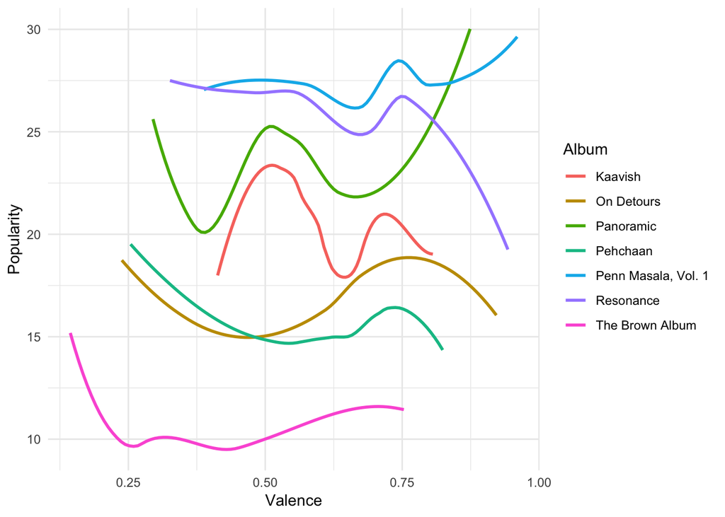